# Exploration of the Red Wine Quality Dataset by Pranesh Ramachandra Murthy

# # #Load the Data

The red wine quality dataset examines the various factors associated with red wine. We can examine how quality rating varies with different factors. We will look at identifying the appropriate combination of variables to achieve the highest quality wine.

# Univariate Plots Section

```
##  [1] "X"                    "fixed.acidity"        "volatile.acidity"
##  [4] "citric.acid"          "residual.sugar"       "chlorides"
##  [7] "free.sulfur.dioxide"  "total.sulfur.dioxide" "density"
## [10] "pH"                   "sulphates"            "alcohol"
## [13] "quality"
```

```
##        X          fixed.acidity   volatile.acidity  citric.acid
##  Min.   :   1.0   Min.   : 4.60   Min.   :0.1200   Min.   :0.000
##  1st Qu.: 400.5   1st Qu.: 7.10   1st Qu.:0.3900   1st Qu.:0.090
##  Median : 800.0   Median : 7.90   Median :0.5200   Median :0.260
##  Mean   : 800.0   Mean   : 8.32   Mean   :0.5278   Mean   :0.271
##  3rd Qu.:1199.5   3rd Qu.: 9.20   3rd Qu.:0.6400   3rd Qu.:0.420
##  Max.   :1599.0   Max.   :15.90   Max.   :1.5800   Max.   :1.000
##  residual.sugar     chlorides       free.sulfur.dioxide
##  Min.   : 0.900   Min.   :0.01200   Min.   : 1.00
##  1st Qu.: 1.900   1st Qu.:0.07000   1st Qu.: 7.00
##  Median : 2.200   Median :0.07900   Median :14.00
##  Mean   : 2.539   Mean   :0.08747   Mean   :15.87
##  3rd Qu.: 2.600   3rd Qu.:0.09000   3rd Qu.:21.00
##  Max.   :15.500   Max.   :0.61100   Max.   :72.00
##  total.sulfur.dioxide    density             pH          sulphates
##  Min.   :  6.00       Min.   :0.9901   Min.   :2.740   Min.   :0.3300
##  1st Qu.: 22.00       1st Qu.:0.9956   1st Qu.:3.210   1st Qu.:0.5500
##  Median : 38.00       Median :0.9968   Median :3.310   Median :0.6200
##  Mean   : 46.47       Mean   :0.9967   Mean   :3.311   Mean   :0.6581
##  3rd Qu.: 62.00       3rd Qu.:0.9978   3rd Qu.:3.400   3rd Qu.:0.7300
##  Max.   :289.00       Max.   :1.0037   Max.   :4.010   Max.   :2.0000
##     alcohol         quality
##  Min.   : 8.40   Min.   :3.000
##  1st Qu.: 9.50   1st Qu.:5.000
##  Median :10.20   Median :6.000
##  Mean   :10.42   Mean   :5.636
##  3rd Qu.:11.10   3rd Qu.:6.000
##  Max.   :14.90   Max.   :8.000
```

```
##                      vars    n   mean     sd median trimmed    mad  min
## X                       1 1599 800.00 461.74 800.00  800.00 593.04 1.00
## fixed.acidity           2 1599   8.32   1.74   7.90    8.15   1.48 4.60
## volatile.acidity        3 1599   0.53   0.18   0.52    0.52   0.18 0.12
## citric.acid             4 1599   0.27   0.19   0.26    0.26   0.25 0.00
## residual.sugar          5 1599   2.54   1.41   2.20    2.26   0.44 0.90
## chlorides               6 1599   0.09   0.05   0.08    0.08   0.01 0.01
## free.sulfur.dioxide     7 1599  15.87  10.46  14.00   14.58  10.38 1.00
## total.sulfur.dioxide    8 1599  46.47  32.90  38.00   41.84  26.69 6.00
## density                 9 1599   1.00   0.00   1.00    1.00   0.00 0.99
## pH                     10 1599   3.31   0.15   3.31    3.31   0.15 2.74
## sulphates              11 1599   0.66   0.17   0.62    0.64   0.12 0.33
## alcohol                12 1599  10.42   1.07  10.20   10.31   1.04 8.40
## quality                13 1599   5.64   0.81   6.00    5.59   1.48 3.00
##                          max   range skew kurtosis    se
## X                    1599.00 1598.00 0.00    -1.20 11.55
## fixed.acidity          15.90   11.30 0.98     1.12  0.04
## volatile.acidity        1.58    1.46 0.67     1.21  0.00
## citric.acid             1.00    1.00 0.32    -0.79  0.00
## residual.sugar         15.50   14.60 4.53    28.49  0.04
## chlorides               0.61    0.60 5.67    41.53  0.00
## free.sulfur.dioxide    72.00   71.00 1.25     2.01  0.26
## total.sulfur.dioxide  289.00  283.00 1.51     3.79  0.82
## density                 1.00    0.01 0.07     0.92  0.00
## pH                      4.01    1.27 0.19     0.80  0.00
## sulphates               2.00    1.67 2.42    11.66  0.00
## alcohol                14.90    6.50 0.86     0.19  0.03
## quality                 8.00    5.00 0.22     0.29  0.02
```

we find from the above summary that all variables are numerical and that there are no categorical variables in the dataset.We can make a few more observations such as that the density values appear to tightly clustered, there is a large difference between the 3rd quantile and max suplhate value, meaning the max value could be a outlier(same could apply for residual sugar). We can also see that the range of the quality variable is from 3 to 8.

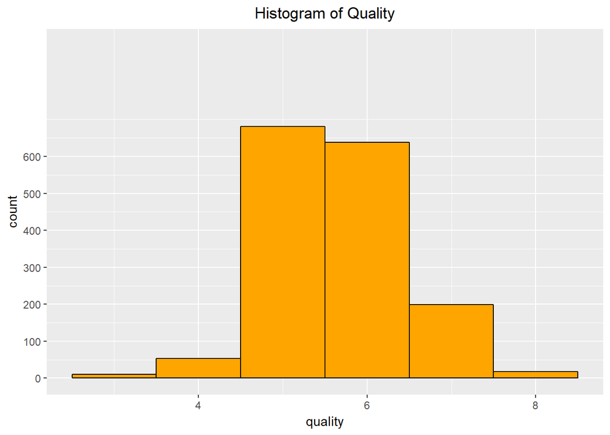

The plot shows us that the count for the lowest and highest quality are very small. This may indicate that lowest and highest quality ratings where only given in extreme conditions. As expected average quality values of 5 and 6 have the most occurences.

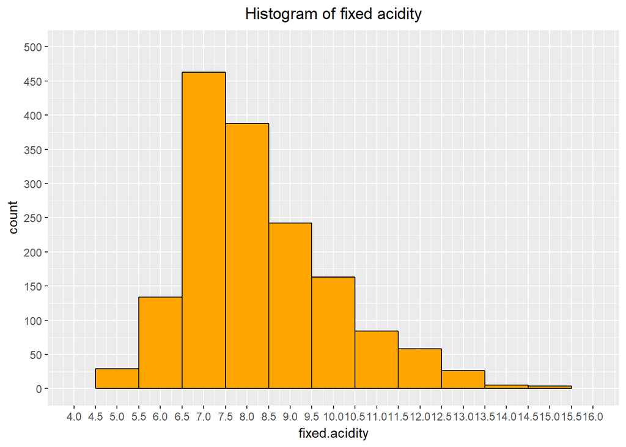

The histogram of fixed acidity shows that the maximum number of values lie between 6.5 and 7.5. We also find that between 14 to 15.5 we have a very small number of values, these are likely special conditions that not likely to occur often. Depending on our analysis, it might be better to classify these points ass outliers when making predictions.

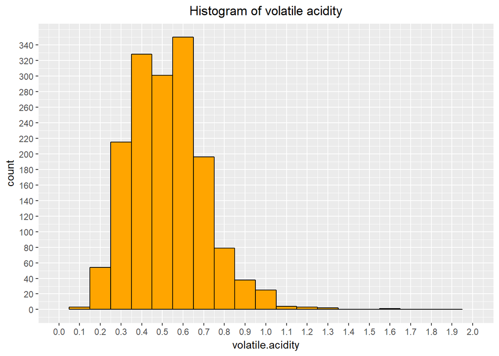

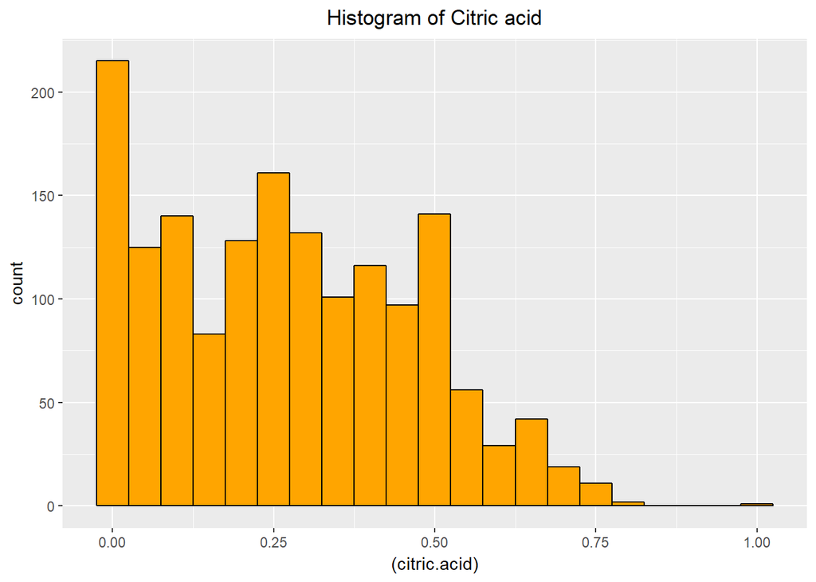

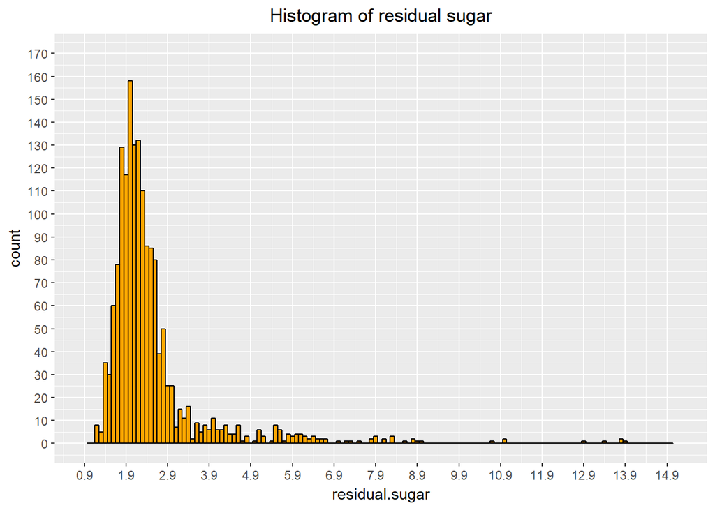

```
## [1] 1.409928
```

we can see from the above plot and standard deviation that the data is closely clustered together.We also see a right-skewed distribution. A transformation is applied to obtain a normal distribution.

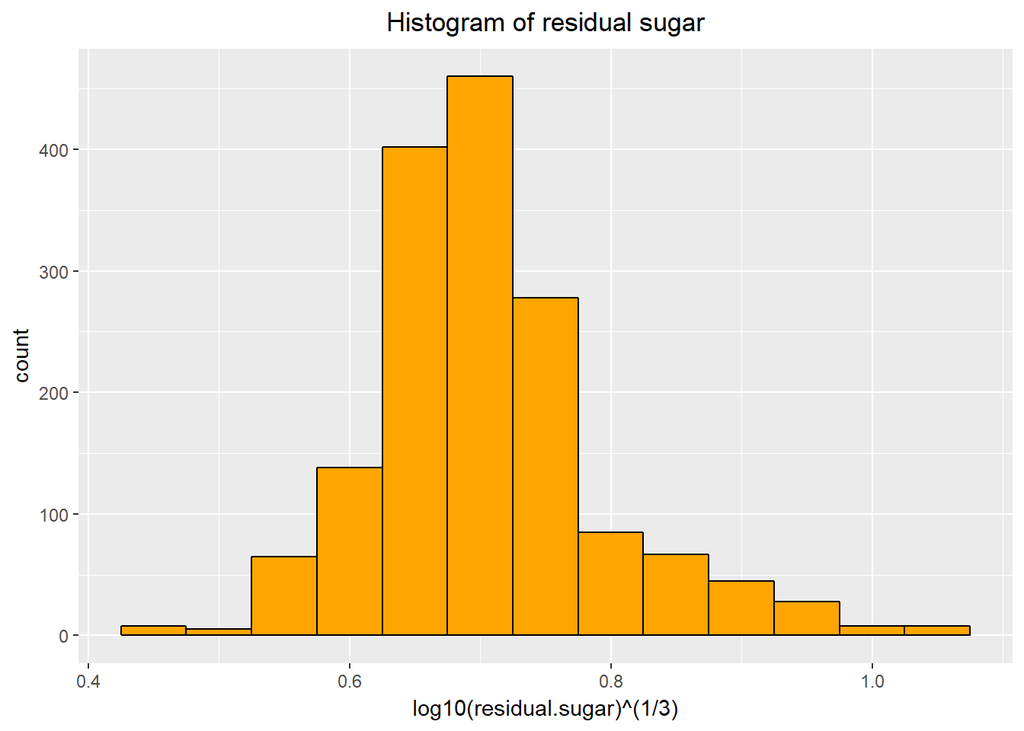

The right skewed histogram is transformed into a normal distribution by using a log10 of cube root transformation. This transformation will be used for future predictions.

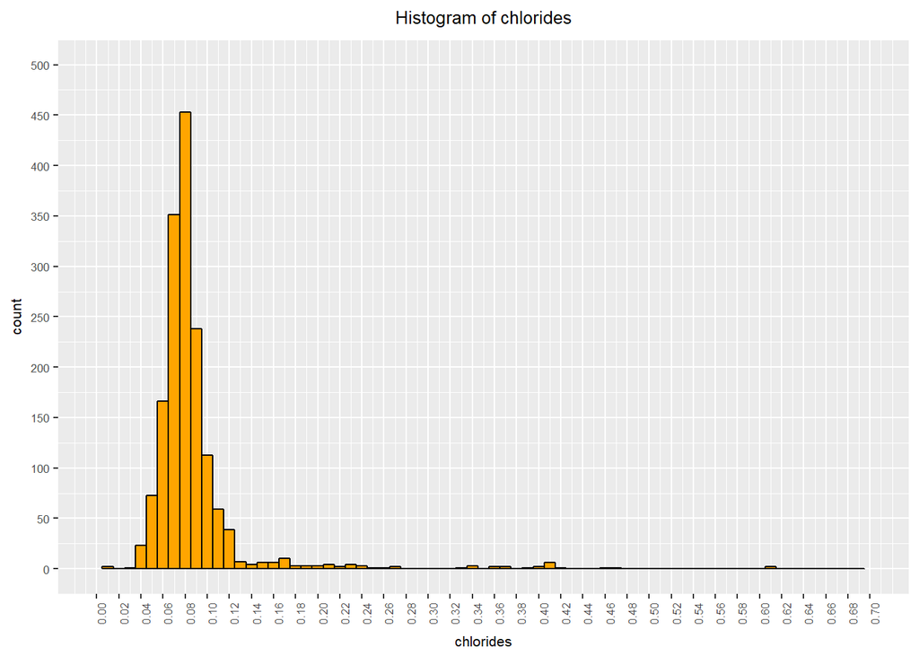

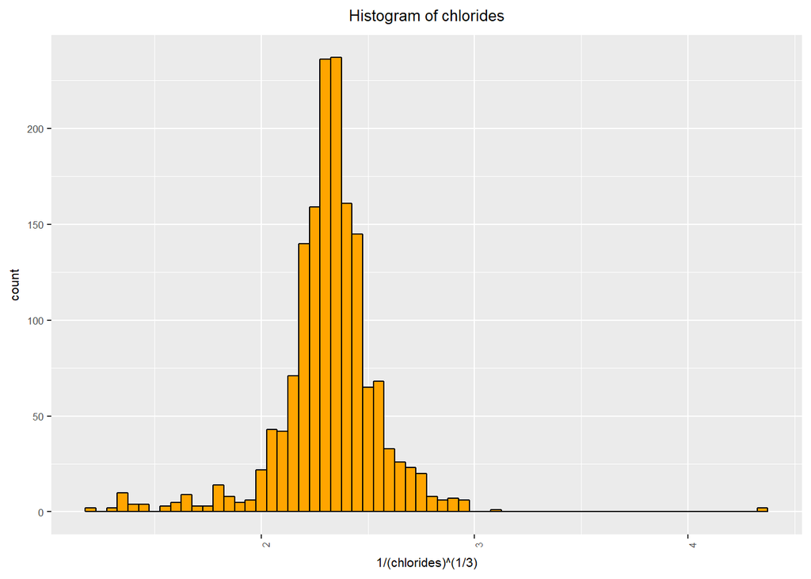

The right skewed histogram is transformed into a normal distribution by using a reciprocal of cube root transformation. This is the only transformation that gives a normal distribution that is not negative.

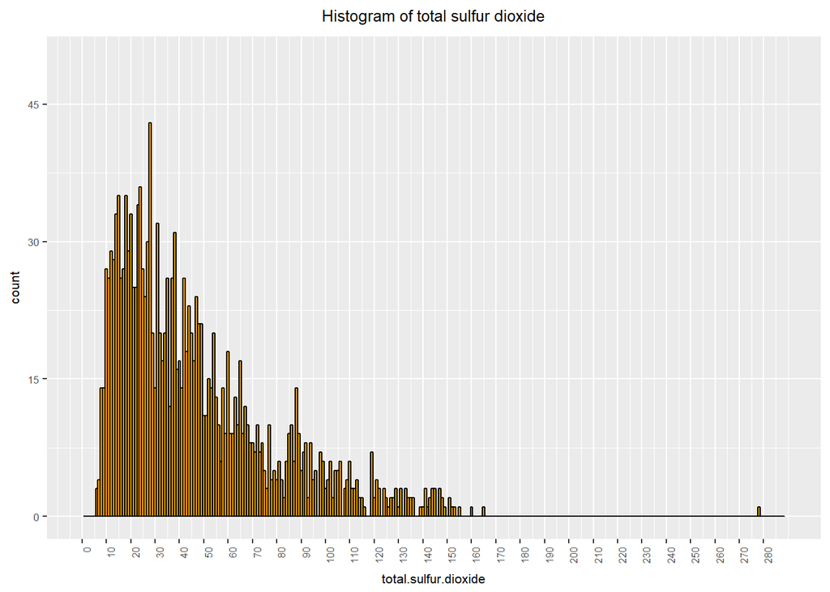

The histogram above shows that the distribution is right skewed. The highest value here is 289. This value can be considered to be an outlier. This can be said because 289 is greater than Q1+(1.5*IQR), which is 82. The Q1 and Q2 values can seen from the summary statistics below.

```
##    Min. 1st Qu.  Median    Mean 3rd Qu.    Max.
##    6.00   22.00   38.00   46.47   62.00  289.00
```

The difference of the first and third quartiles gives us the IQR. The Q1+(1.5*IQR) shows that 289 should be classified as an outlier. But to change the distribution to normal we use a log10 transformation on total.sulfur.dioxide. This histogram is shown below.

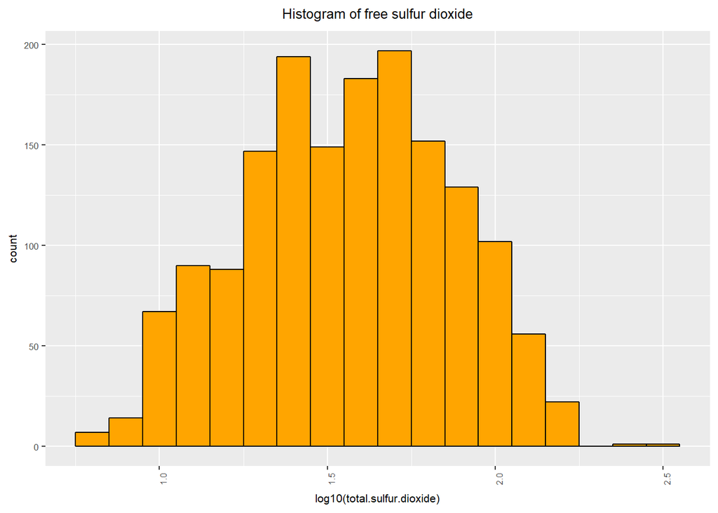

The right skewed histogram is transformed into a normal distribution by using a log10 transformation. This transformation will be used for future predictions.

[figure not shown]

The histogram is right skewed, let us now transform the data and check for a normal distribution.

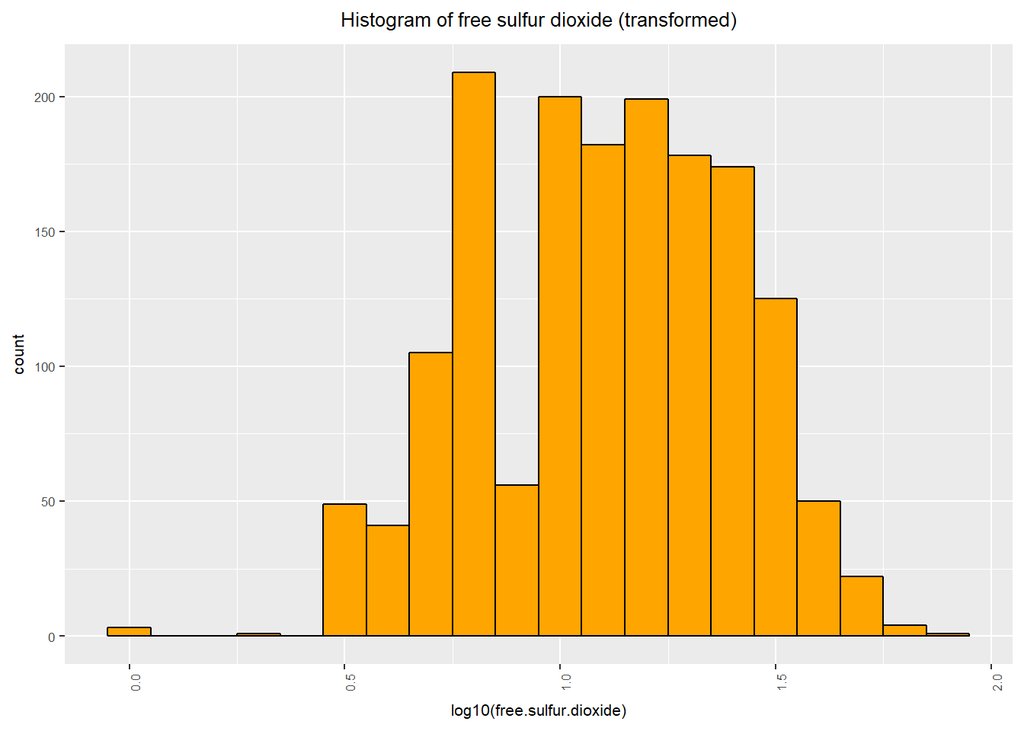

The histogram after transformation appears to be closer to a normal distribution. Thus we will use the transformed variable for our predictions.

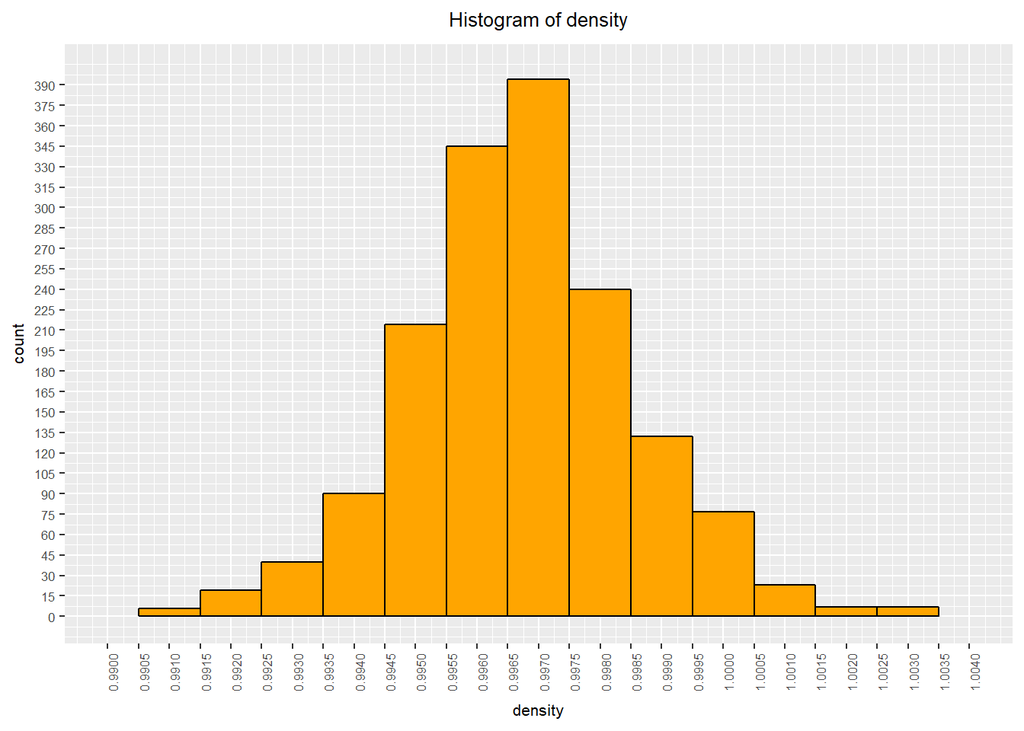

The histogram appears to be normally distributed. We can see from the histogram that the highest number of values occur between 0.9965 to 0.9975. The normal distribution can also be explained by the mean, median and mode values being close to each other.

```
##    Min. 1st Qu.  Median    Mean 3rd Qu.    Max.
##  0.9901  0.9956  0.9968  0.9967  0.9978  1.0037
```

The median, median and mode are fairly close to each other, with mode shown in the plot. These values along with the histogram confirm that the above distribution is normal.

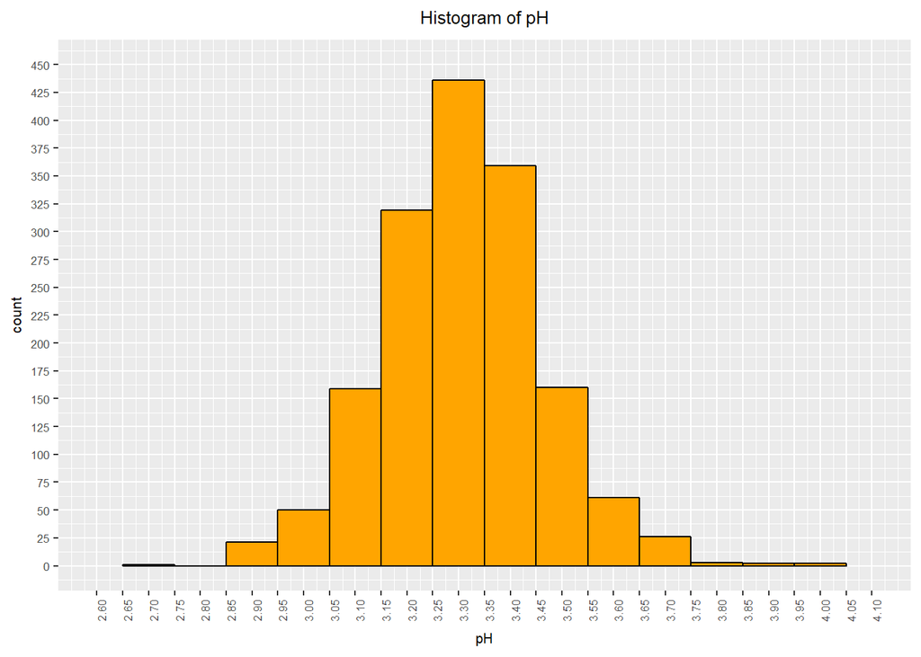

We can see that the pH values are normally distributed. The highest number of values are seen between 3.25 to 3.35. The mean, median and mode are also close to eachother which corresponds with the normal distribution.

```
##    Min. 1st Qu.  Median    Mean 3rd Qu.    Max.
##   2.740   3.210   3.310   3.311   3.400   4.010
```

The mean, median and mode values are fairly close to eachother. These statistics combined with our histogram shown that the distribution is normal.

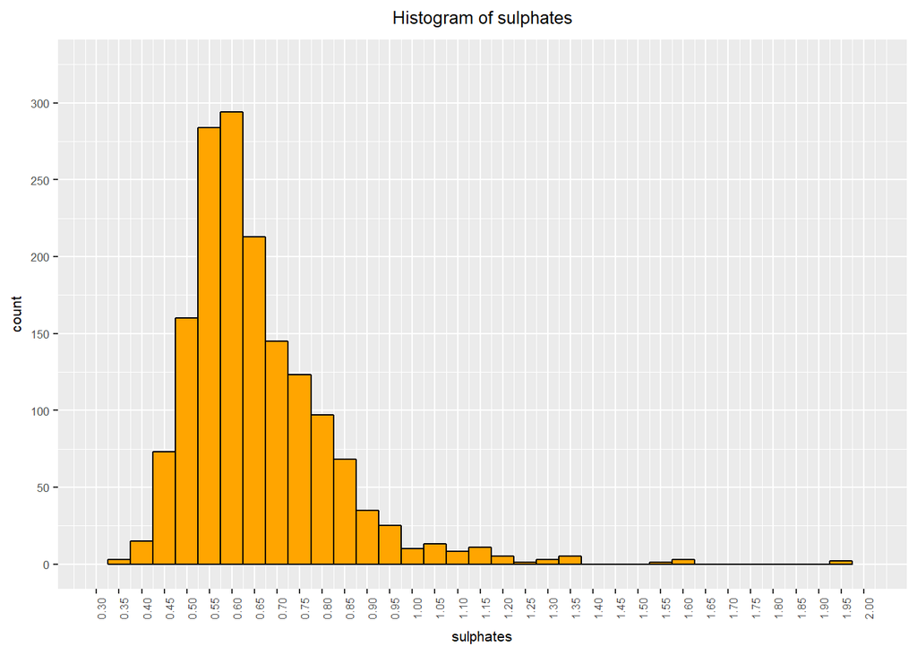

We can see from above that the histogram is right skewed. There largest value of 1.95 is greater than Q1+(1.5*IQR), which is 0.82. So 1.95 can be classified as an outlier. The right skewed distribution can be explained by the mean being greater than the median and mode(0.57-0.625).

```
##    Min. 1st Qu.  Median    Mean 3rd Qu.    Max.
##  0.3300  0.5500  0.6200  0.6581  0.7300  2.0000
```

We can see from above that the mean is greater than the median. This statistic combined with the histogram shows us the right-skewness of our plot.

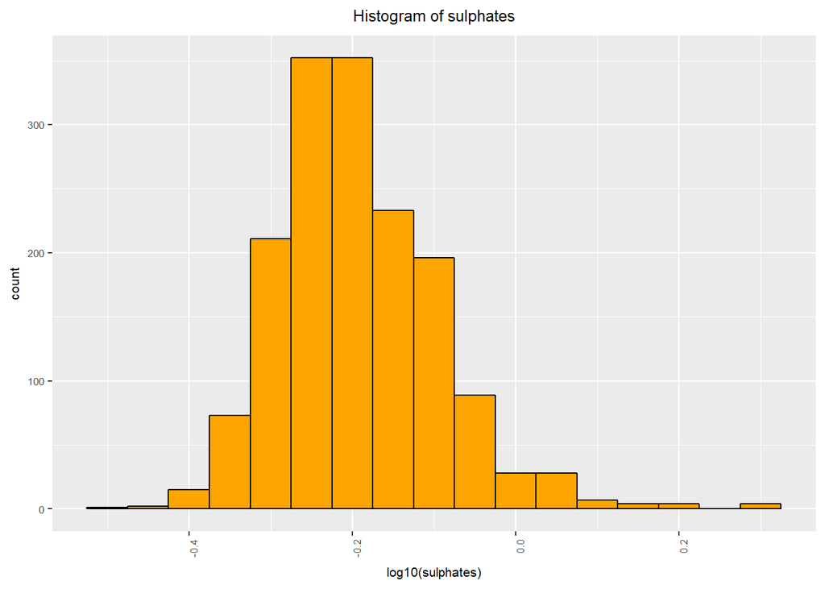

The log transformed data is closer to a normal distribution. We can use this transformed data for our analysis.

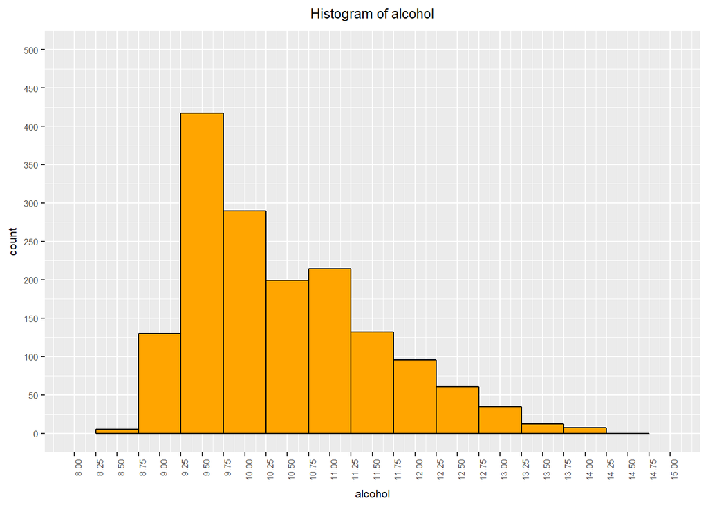

The histogram shown above is slightly right skewed.The maximum count of values occur betwen 9.25 and 9.75. The right skewness is also shown in the summary where the mean is greater than the median and mode.

```
##    Min. 1st Qu.  Median    Mean 3rd Qu.    Max.
##    8.40    9.50   10.20   10.42   11.10   14.90
```

The mean is greater than the median as shown in the summary statistic. The distribution of data and the mean being greater than the median show us the variable data values are right skewed.

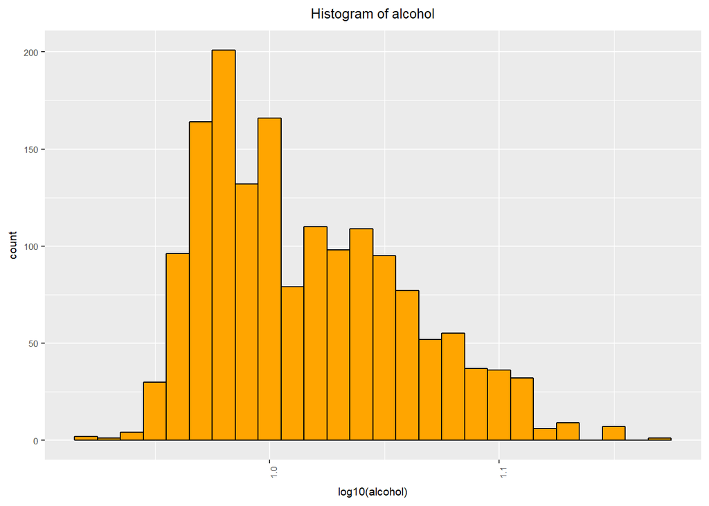

# Log10 transformation of alcohol give us a slightly better distribution of data. This transformed data will be used for all future predictions.

# Univariate Analysis

### What is the structure of your dataset?

The Red wine quality dataset consists of 12 variables and 1599 values. The dataset has zero null values. All variables appear to numerical varaibles.

### What is/are the main feature(s) of interest in your dataset?

The main feature of the dataset is the quality variable which gives us a result describing the wine quality. The quality variable values are based on the combination of all other variables. This variable can help us identify and set limits on what characteristics are popular in wine.

### Did you create any new variables from existing variables in the dataset?

No new variables have been created. Each variable on first examination appear to independent of other variables.

### Of the features you investigated, were there any unusual distributions? Did you perform any operations on the data to tidy, adjust, or change the form of the data? If so, why did you do this?

# Bivariate Plots Section

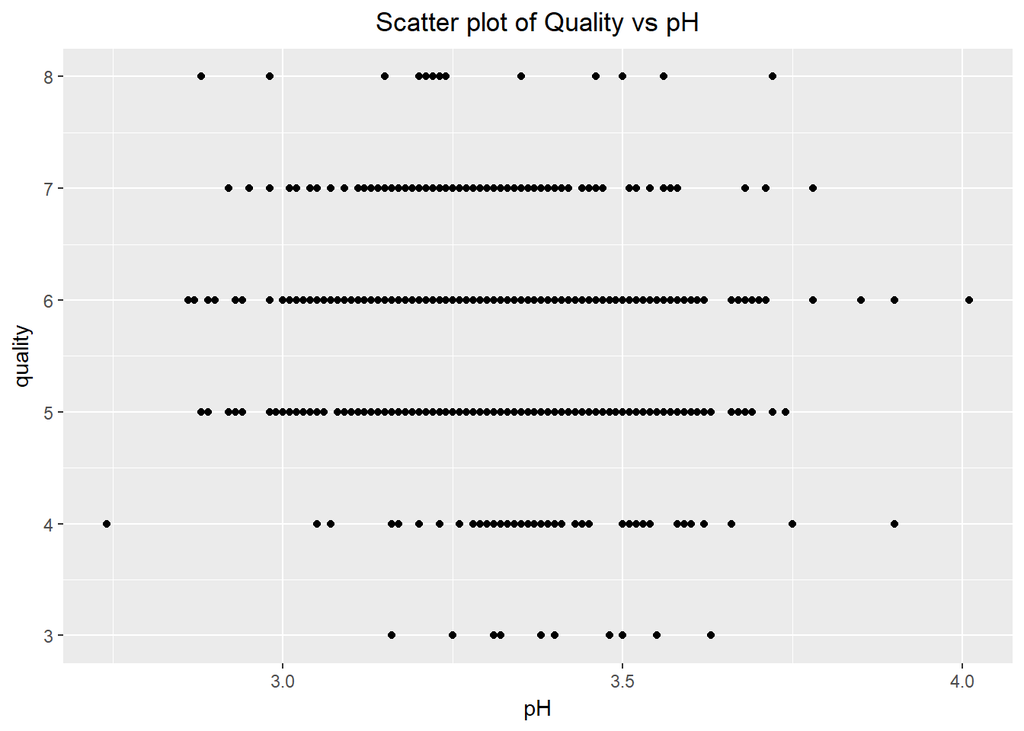

We know that the quality values are integers, which results in us getting straight lines when we plot the points coresponding to pH values. We can clearly see that most ph values are clusered between 3 to 3.6. We can also see that similar pH values have different quality ratings, this should mean that other variables have greater impact on quality. We can study this further by plotting a correlation plot.

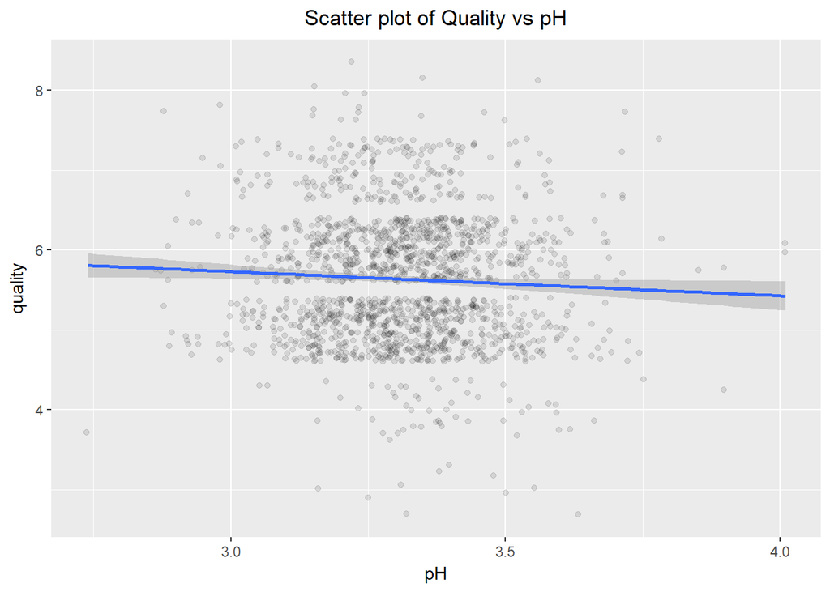

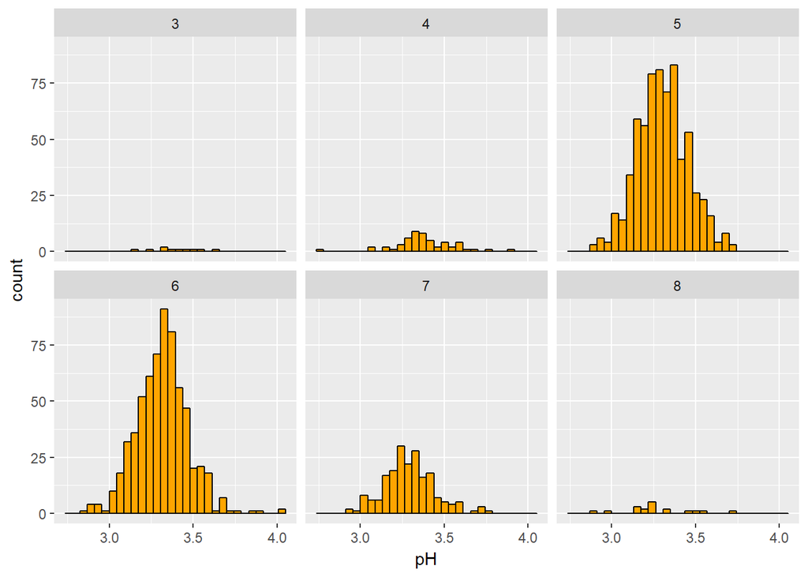

The historgram above shows how the pH value is distributed accross the quality levels. We see that most pH values fall in the quality levels of 5, 6 and 7.

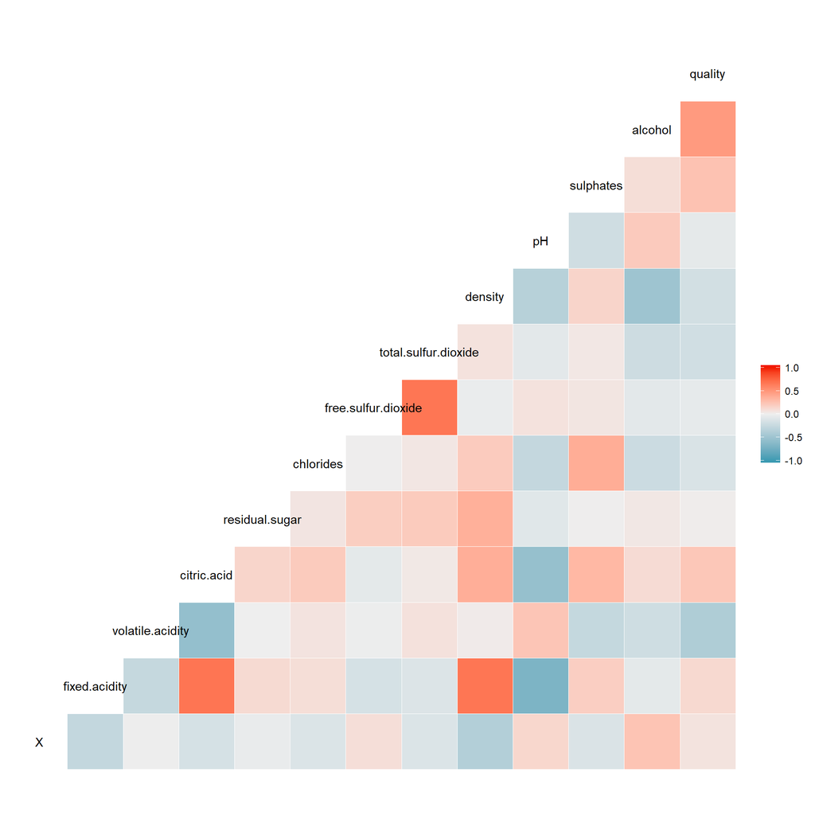

We find from the correlation plots that the variables below have high correlations between them.

1. fixed acidity and citric acid
2. total sulphur dioxide and free sulphur dioxide
3. Alcohol and quality
4. fixed acidity and density

We also find correlation plots with high negative correlation values(>-0.5). 1. pH vs fixed.acidity 2. pH vs citric acid 3. citric acid vs volatile acid

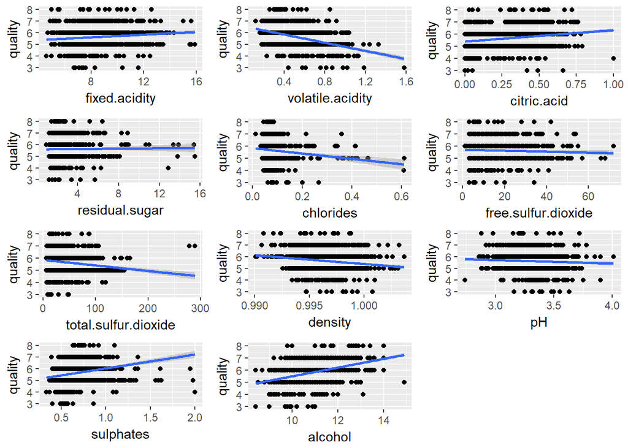

We can see the relationship between quality and different variables. We can also identify from the regression line, the nature of relationship. Quality and alcohol as indicated from the plot and the correlation value. We would normally expect,some variation in variable values for higher quality levels but here we observe that the same variable value are seen at high and low quality levels. Maybe scatter plot does not show the best results for these variables.

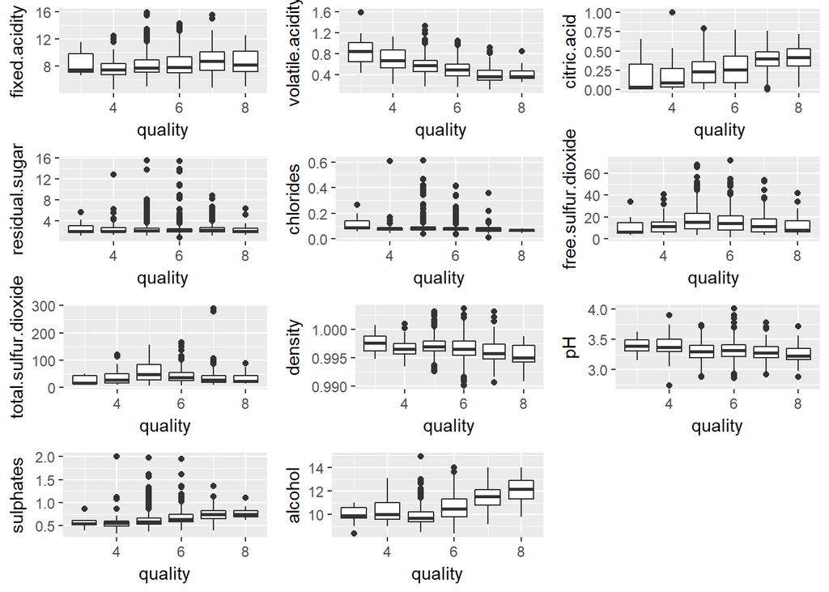

We can see how other variables change for each quality level. We can easily identify outliers at each level and we see what variables have a positive relationship. These are given below 1. Alcohol 2. citric acid 3. fixed acidity 4. sulpahtes

Variables with a negative correlation are also shown below. 1. density 2. pH 3. Volatile acid

The quality variable is used to create a new categorical variable call quality_labels. Quality labels will help divide the data into bad ,average and good quality wine.

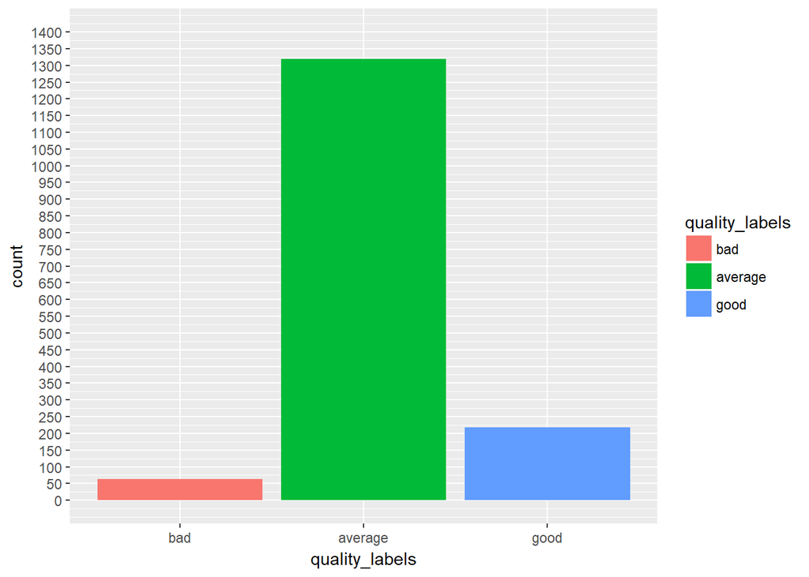

The histogram above shows that most values in our dataset have a quality rating of either 5 or 6. This is categorized as average wine quality. The variable counts with quality rating of bad or good is less than half of the average quality value counts.

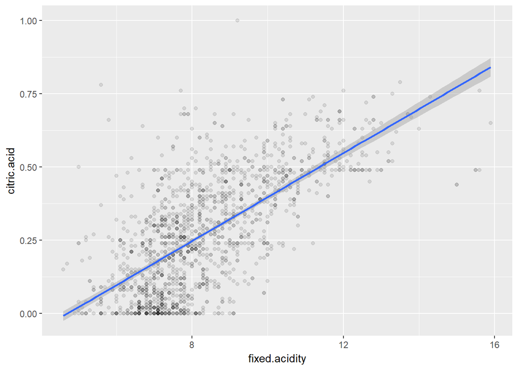

This plot shows a trend where citric acid values increase with higher fixed.acidity values. This is to be expected as citric acid is often added to increase acidity. The plot shows the data to be well distributed. Highest cluster of points are seen at citric acid value of 0.

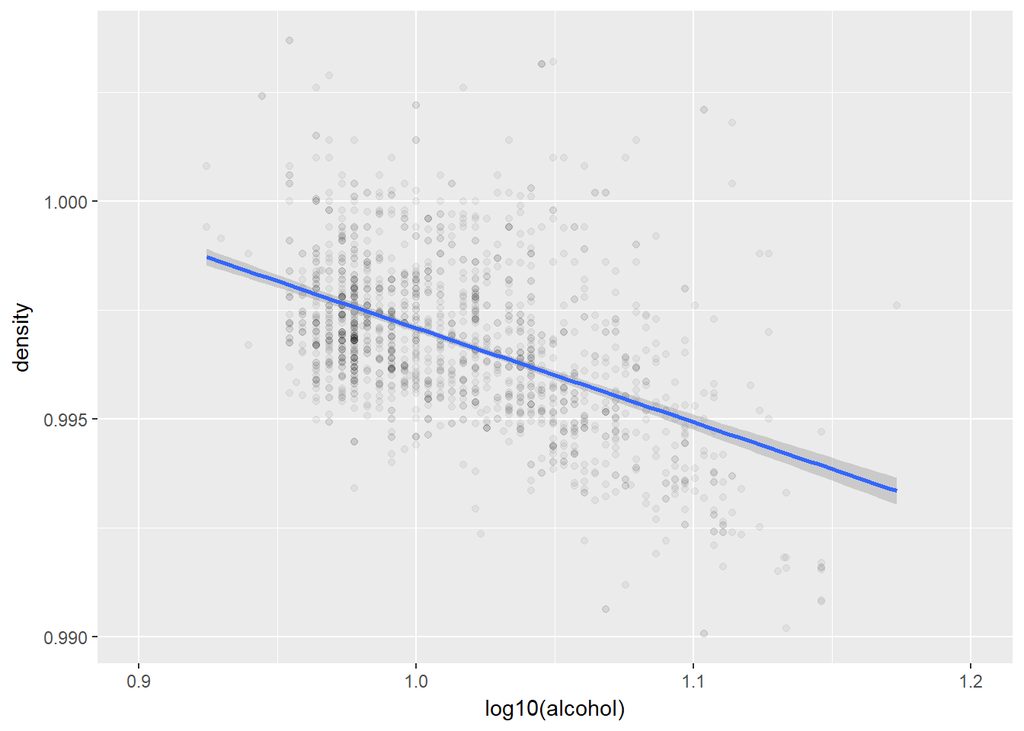

This relationship is interesting as the density values tend to decrease with alcohol content.This is unexpected. Higher density should mean higher alcohol content as density of wine is made of concentration of alcohol, sugar and disolved content. Additionally, alcohol and quality are positively correlated with each other. It will be interesting to see where different quality levels are placed in this plot.

We can also see that the most data points are clustered at log10 alcohol values of 0.97 and 0.98. The corresponding density values being between 0.995 and 0.9975.

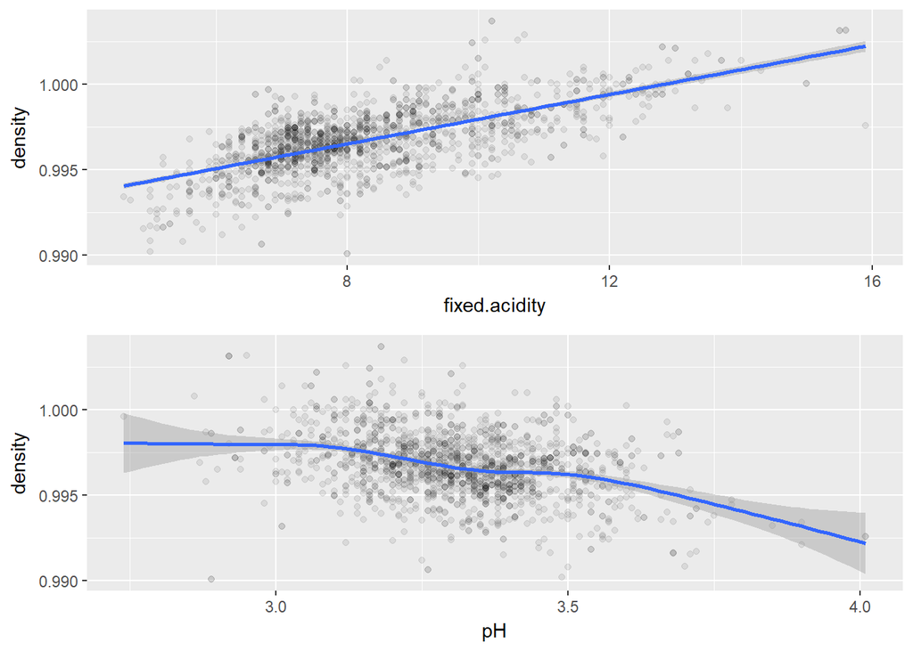

This relationship is interesting in that density values increase with fixed.acidity. The fixed acidity increases with lower pH values so this might should that density should increase at lower pH values. This is shown in the 2nd plot below.

We see very small data clusters after adding the alpha value. The data clusters appear close to the trendline. This could mean that the trendline is a good explanation of the relationship between these variables.

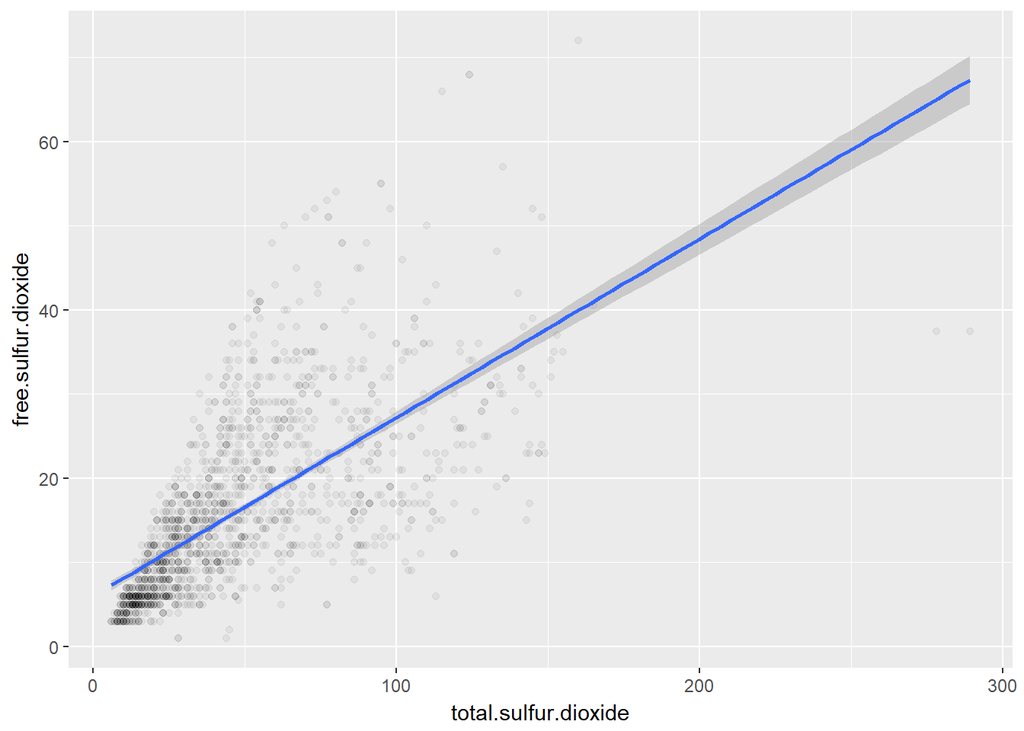

The plot above shows nearly a linear relationship. The correlation value between the 2 variables is 0.668. We can also note that the data is tighly clustered for small values of total and free sulfur dioxide. The dispersion of data increases as the values increase. We also see 2 points with extremely high total.sulfur dioxide values, they are likely outliers. We did recommend earlier that we apply a log10 transformation to total and free sulfur dioxide.

With the addition of alpha, we can further confirm that data values are closely clustered at low total and free sulfur dioxide values.

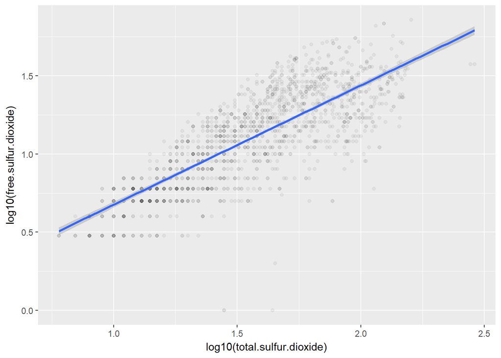

```
##
##  Pearson's product-moment correlation
##
## data:  log10(red_wine_q$total.sulfur.dioxide) and log10(red_wine_q$free.sulfur.dioxide)
## t = 50.575, df = 1597, p-value < 2.2e-16
## alternative hypothesis: true correlation is not equal to 0
## 95 percent confidence interval:
##  0.7650258 0.8027661
## sample estimates:
##       cor
## 0.7846217
```